# Introduzione a R

## `tidyverse()`

`tidyverse()` è un pacchetto specifico pensato per il data science che permette un utilizzo più agevole e forse inutitivo delle funzioni di base di R.

```r
install.packages("tidyverse") # installa il pacchetto ( va fatto solo una volta)
library(tidyverse) # carica la libreria e la rende disponibile
```

Tutto il suo funzionamento si base sull’operatore %>% (Pipe)

Lo si ottiene con la combinazione di tasti `shift + ctrl + M`

La logica del suo funzionamento è molto semplice:

```r
object %>%   # oggetto su cui si vogliono svolgere le operazioni
  grouping %>% # eventuali variabili di ragguppamento
  function # la o le funzioni che si vogliono applicare
```

## Statistice descrittive con `tidyverse`

Per ottenere le statistiche descrittive (media e ds) del punteggio di benessere e autostima considerando le variabili di raggruppamento siblings e genere

```r
benessere %>%  # oggetto (dataframe) su cui si vuole lavorare
  group_by(siblings, genere) %>%  # variabili di raggruppamento
  summarise(m_benessere = mean(score_ben),  # funzioni che si vogliono applicare e variabili di confronto
            sd_benessere = sd(score_ben),
            m_au = mean(score_au),
            sd_au = sd(score_au))
```

```
# A tibble: 4 × 6
# Groups:   siblings [2]
  siblings genere m_benessere sd_benessere  m_au sd_au
  <chr>     <int>       <dbl>        <dbl> <dbl> <dbl>
1 no            1        13.9         3.25  33.3  4.45
2 no            2        14.5         3.31  32.1  3.00
3 yes           1        14.7         3.35  33.0  3.74
4 yes           2        14.3         3.23  33.0  4.40
```

## Your turn!

- Calcolare minimo, massimo e mediana di `score_au` e `score_ben` con `tidyverse`
- Importare il dataset `babies` e calcolare media e deviazione standard delle variabili `peso` e `altezza` con `tidyverse`

**See solution**

```r
benessere %>%
    summarise(min_ben = min(score_ben),
            max_ben = max(score_ben),
            median_ben = median(score_ben),
            min_au = min(score_au),
            max_au = max(score_au),
            median_au = median(score_au))
```

```
  min_ben max_ben median_ben min_au max_au median_au
1       9      26         14     25     48        32
```

```r
# importa il dataset babies
babies = read.table("data/babies.tab")
# calcola le statistiche descrittive
babies %>%
  summarise(mean_weight = mean(peso),
            sd_weight = sd(peso),
            mean_height = mean(altezza),
            sd_height = sd(altezza))
```

```
  mean_weight sd_weight mean_height sd_height
1    9.969853  3.274042    74.87698  16.31357
```

# Grafici

Si hanno a disposizione i grafici “tradizionali” per cui non è necessario scaricare ulteriori pacchetti e i grafici prodotti con ggplot, per cui è necessario scaricare il pacchetto `ggplot2`

Per entrambe le tipologie:

- Funzioni di alto livello $\rightarrow$ Quelle che effettivamente producono il grafico
- funzioni di basso livello $\rightarrow$ Quelle che lo rendono più carino

## Grafici tradizionali

### Funzioni di alto livello:

```r
plot()      # scatter plot, specialized plot methods
boxplot()
hist()      # histogram
qqnorm()    # quantile-quantile plot
barplot()
pie()       # pie chart
pairs()     # scatter plot matrix
persp()     # 3d plot
contour()   # contour plot
coplot()    # conditional plot
interaction.plot()
```

`demo(graphics)` produce un tour guidato di tutte le funzioanalità grafiche!

### Low level functions

```r
points()       # add points
lines()        # add lines
rect()
polygon()
abline()       # add line with intercept a, slope b
arrows()
text()         # add text in plotting region
mtext()        # add text in margins region
axis()         # customize axes
box()          # box around plot
legend()
```

Il layout dei plot è molto importante ed è costituito da due regioni principali:

- La regione del plot (quella che effettivamente contiene il plot)
- La regione dei margini (dove sono contenuti i margini e le etichette degli assi)

Ad esempio, per ottenere uno scatterplot:

```r
x <- runif(50, 0, 2) # genera 50 valori casuali da una distribuzione uniforme
y <- runif(50, 0, 2) # genera 50 valori casuali da una distribuzione uniforme
# produce il plot
plot(x, y, # variabili sull'asse x e y, rispettivamente
     main="Title", # titolo del grafico
     sub="Subtitle", # sottotitolo
     xlab="x-label", # etichetta asse x
     ylab="y-label") # etichetta asse y
text(0.6, 0.6, "Text at (0.6, 0.6)") # aggiunge del testo al grafico
# aggiunge linee orizzontal e verticali
abline(h=.6, v=.6, lty=2)
```

[output not shown]

## `plot()`

```r
plot(x) # una variabile
plot(x, y) # scatter plot
plot(y ~ x) # scatter plot (codice alternativo)
```

Si uò cambiare il colore degli elementi del grafico anche condizionando su specifiche variabili di raggruppamento:

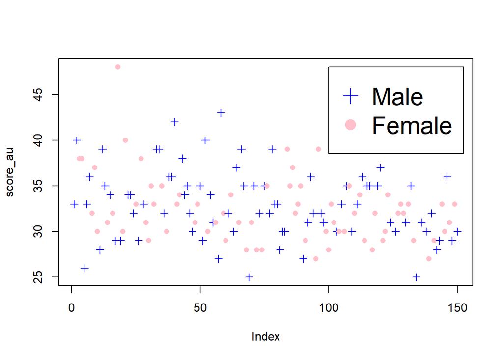

```r
with(benessere,
     plot(score_au,
          col = ifelse(genere == 1, "blue", "pink"), # condiziona il colore tale per cui se è maschio è blu
          pch = ifelse(genere == 1, 3, 16))) # condiziona la forma del puntino
# inserisce la legenda
legend(x = 100, y = 48, # coordinate specifiche per la legenda
       c("Male", "Female"), # etichette
       pch = c(3, 16),  # mappe dei puntini
       col =c("blue", "pink"), # mappe del colore
       cex = 2) # grandezza del testo
```

## Esempio di scatterplot: `plot(x, y)`

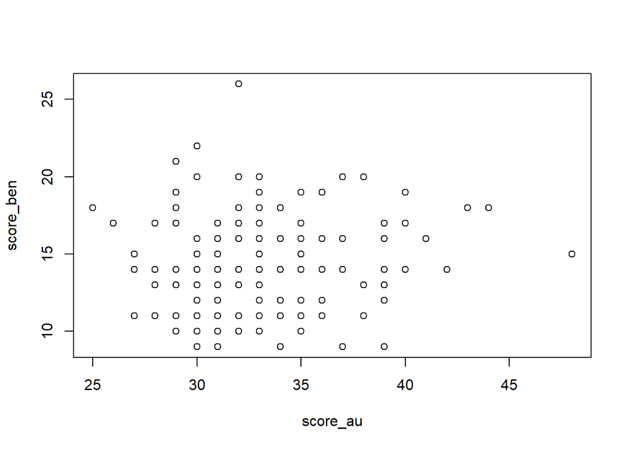

```r
with(benessere,
     plot(score_au, score_ben))
```

## Esempio di scatterplot: `plot(y ~ x)`

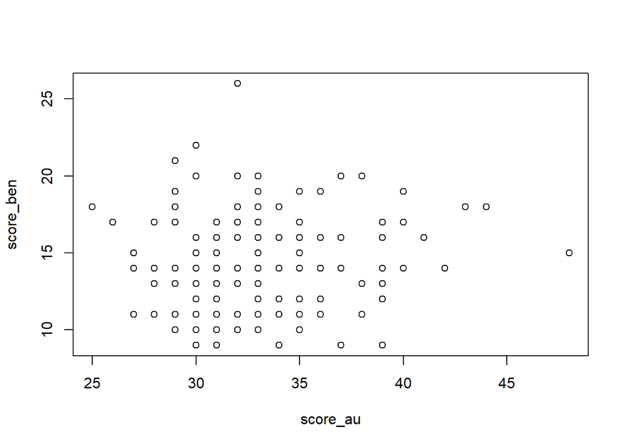

```r
with(benessere,
     plot(score_ben ~ score_au))
```

Agli scatterplot si può aggiungere anche la linea che indica il modello di regressione

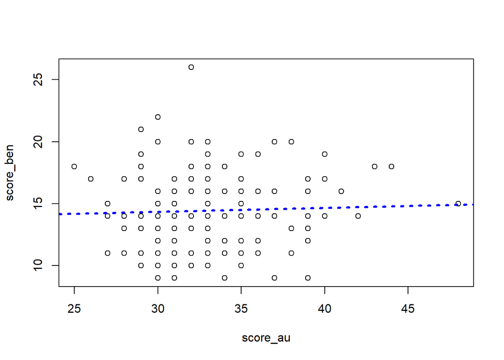

```r
with(benessere,
     plot(score_ben ~ score_au))
# aggiunge la linea
abline(lm(score_ben ~ score_au, data = benessere),# specifica il modello di regressione per le coordinate della linea
          col = "blue",
       lty = 3, # tipo di linea
       lwd = 3) # spessore della linea
```

## Esempio di scatterplot quando x è una variabile categorica: `plot(y ~ x)`

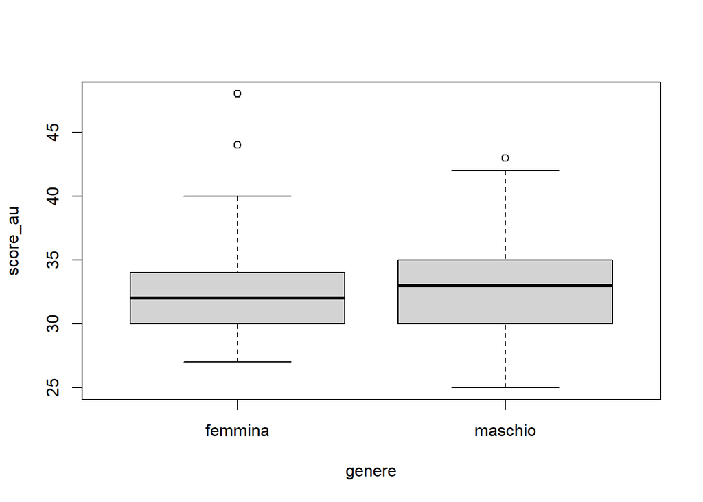

```r
benessere$genere <- factor(ifelse(benessere$genere == 1,
                           "maschio", "femmina"))
plot(score_au ~ genere, data = benessere)
```

equivale ad usare la funzione `boxplot(y ~ x)`

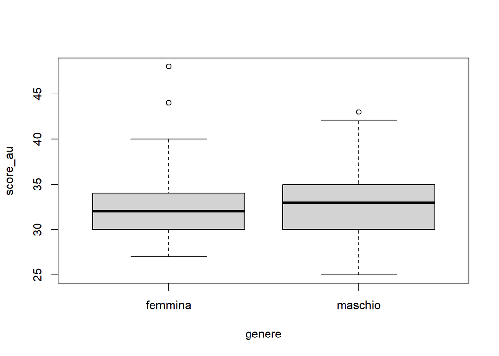

```r
boxplot(score_au ~ genere, data = benessere)
```

## `hist()`

Serve per produrre l’istogramma delle frequenze per variabili continue

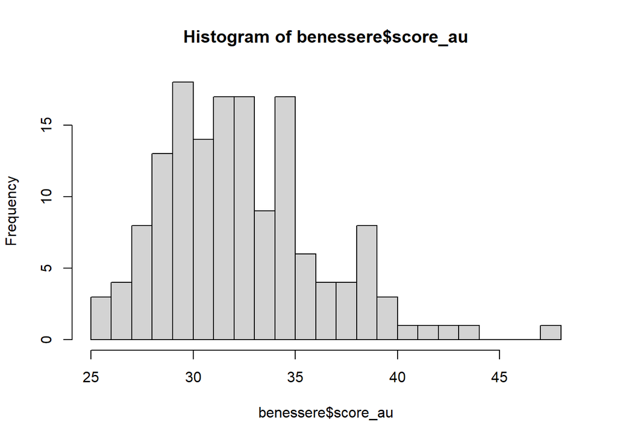

```r
hist(benessere$score_au, # la variabile che si vuole plottare
     breaks = 20) # il numero di bins
```

Si può plottare la funzione di densità della variabile plottat in istogramma (solo per variabili conitnue)

**Codice**

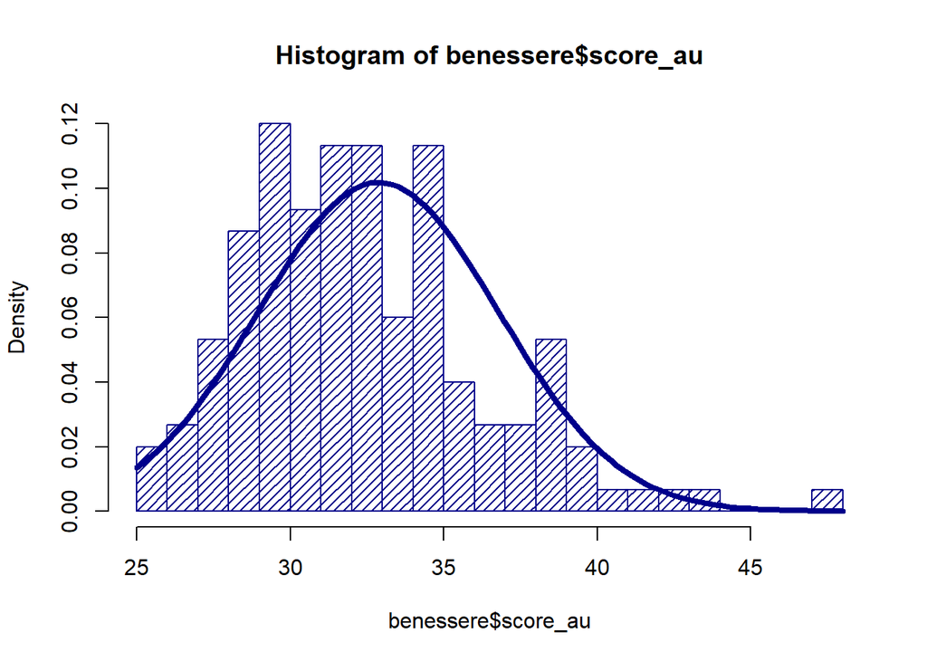

```r
hist(benessere$score_au,
     density=20, # va specificato che si vuole aggiungere l'istogramma
     breaks=20,
     prob=TRUE, # va specificato che sull'asse delle y dovranno esserci valori di probabilità
     col = "darkblue")
curve(dnorm(x, mean=mean(benessere$score_au),  # si utilizza la funzione dnorm() per avere la densità
            sd=sd(benessere$score_au)),
      col="darkblue", lwd=4,
      add=TRUE, # fa in modo che la funzione di densità venga aggiunta al grafico
      yaxt="n")
```

## Modificare il layout

Si possono plottare più grafici in un’unica finesra modifcando il layout

```r
par(mfrow=c(nrows, ncolumns)) #  i pannelli vengono riempiti per riga
par(mfcol=c(nrows, ncolumns)) # i pannelli vengono riempiti per colonna
```

## Multi plot: Righe

**Codice**

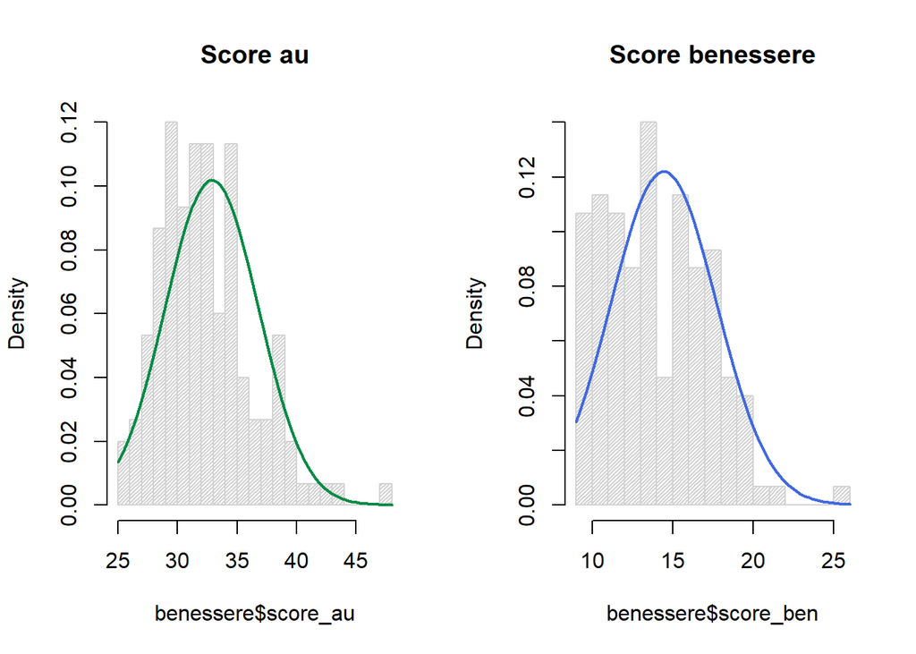

```r
par(mfrow=c(1, 2)) # specifica che si vuole una riga e due colonne

hist(benessere$score_au,density=50, breaks=20, prob=TRUE,
     main = "Score au")
curve(dnorm(x, mean=mean(benessere$score_au),
            sd=sd(benessere$score_au)),
      col="springgreen4", lwd=2, add=TRUE, yaxt="n")

hist(benessere$score_ben,density=50, breaks=20, prob=TRUE,
     main = "Score benessere")
curve(dnorm(x, mean=mean(benessere$score_ben),
            sd=sd(benessere$score_ben)),
      col="royalblue", lwd=2, add=TRUE, yaxt="n")
```

## Multi plot: colonne

**Codice**

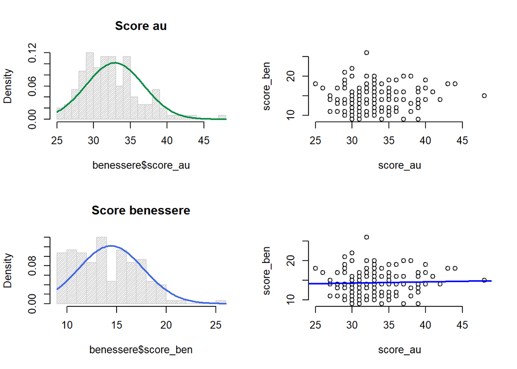

```r
par(mfcol= c(2,2))
# primo pannello in alto a sinistra
hist(benessere$score_au,density=50, breaks=20, prob=TRUE,
     main = "Score au")
curve(dnorm(x, mean=mean(benessere$score_au),
            sd=sd(benessere$score_au)),
      col="springgreen4", lwd=2, add=TRUE, yaxt="n")
# secondo pannello in basso a sinistra
hist(benessere$score_ben,density=50, breaks=20, prob=TRUE,
     main = "Score benessere")
curve(dnorm(x, mean=mean(benessere$score_ben),
            sd=sd(benessere$score_ben)),
      col="royalblue", lwd=2, add=TRUE, yaxt="n")
# terzo pannello in alto a destra
with(benessere,
     plot(score_au, score_ben, frame = FALSE))
# quarto pannello in basso a adestra
with(benessere,
     plot(score_au, score_ben, frame = FALSE))
abline(lm(score_ben ~ score_au, data = benessere), col = "blue", lwd = 2)
```

## `barplot()`

Serve per ottenere il plot delle frequeunze per le categorie di una variabile categoriale

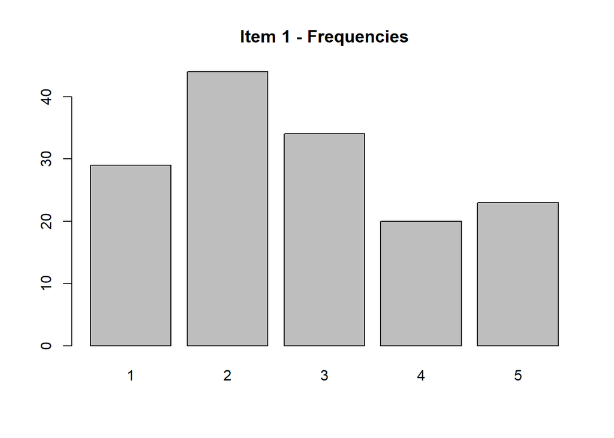

```r
freq_item1 = table(benessere$item1)
barplot(freq_item1,
        main = "Item 1 - Frequencies")
```

## `barplot()`: Frequenze relative

è necessario calcolare prima le proporzioni sul totale per ogni categoria di risposta

**Codice**

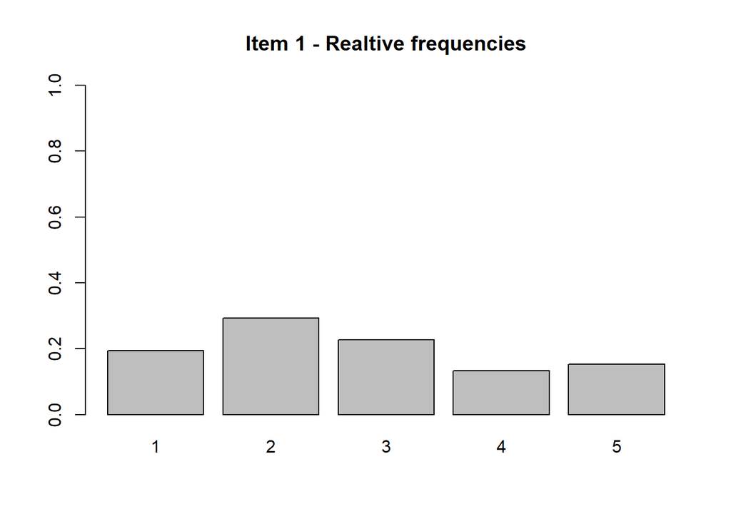

```r
perc_item1 = freq_item1/sum(freq_item1)
barplot(perc_item1,
        ylim = c(0, 1), # setta l'asse delle y ad essere compreso tra 0 e 1
        main = "Item 1 - Realtive frequencies")
```

Nel caso si voglia vedere la frequenza relativa in vase a una variabile di raggruppamento, vanno prima calcolate le frequenze relative per ognuno dei gruppi considerati

**Codice**

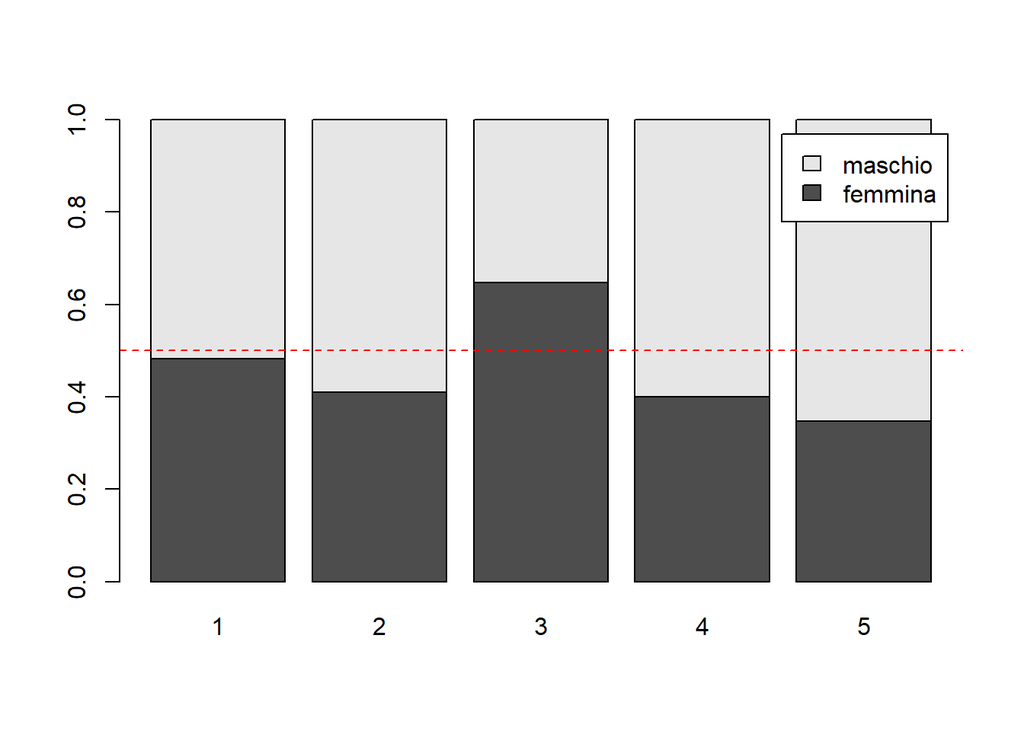

```r
# tabella a doppia entrata delle frequeunze di risposta all'item 1 in base al genere
perc_item1_gender = table(benessere$genere, benessere$item1)
# calcola le frequeunze relative sul totale delle risposte per il livello 1
perc_item1_gender[1,] = perc_item1_gender[1,]/table(benessere$item1)
# calcola le frequeunze relative sul totale delle risposte per il livello 2
perc_item1_gender[2,] = perc_item1_gender[2,]/table(benessere$item1)
# produce il plot, automaticamente suddiviso nei due gruppi
barplot(perc_item1_gender, ylim=c(0,1),
        legend = rownames(perc_item1_gender))
abline(h = .5, lty = 2, col = "red")
```

## Multi plot: Esempio su tutti gli item

Si può ottenere un grafico come quello illustrato in precedenza per tutti gli item, ripetendo il procedimento per oguno degli item attraverso l’applicazione di un ciclo for

**Codice**

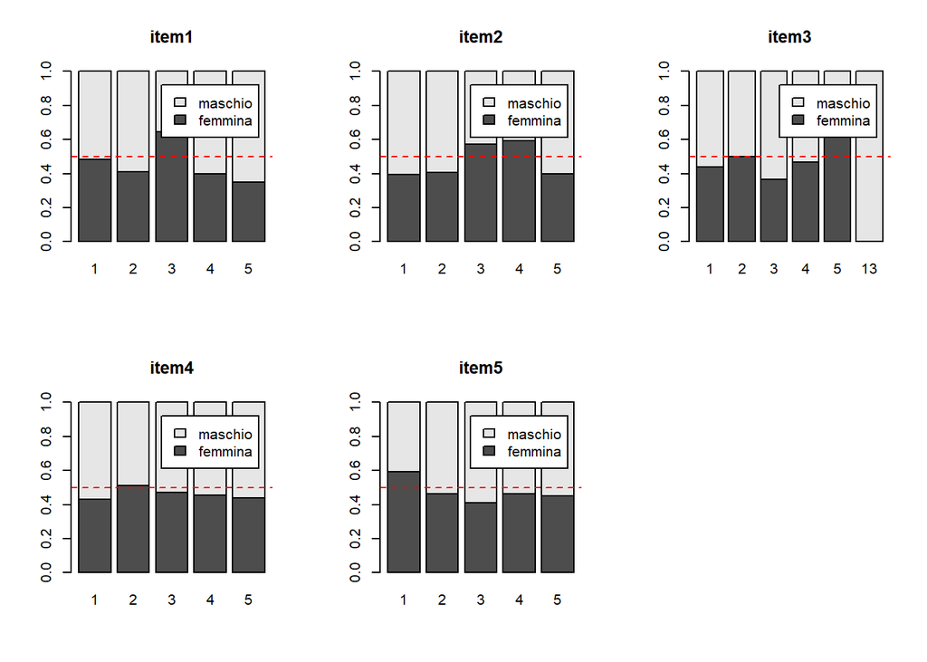

```r
# isola le etichette degli item di interesse
item_ben = benessere[, grep("item", colnames(benessere))]
# predispone il layout per ospitare tutti i grafici
par(mfrow = c(2, round(ncol(item_ben)/2  + 0.2)))
temp = NULL # crea una variabile temporanea dove mettere le tabelle delle frequeunze necessarie per il plot
for (i in 1:ncol(item_ben)) { # il ciclo itera per ognuno degli item
  temp = table(benessere$genere, item_ben[,i]) # calcola le frequeunze per ogni item a sceonda del genere
  for (j in 1:nrow(temp)) {
    temp[j,] = temp[j,]/table(item_ben[,i]) # calcola le frequeunze percentuali
  }
barplot(temp, ylim=c(0,1), legend = rownames(temp), # produce il plot
        main = colnames(item_ben)[i])
abline(h = .5, lty = 2, col = "red")
}
```

## `interaction.plot()`

è possibile anche ottenere un grafico che mostra la relazione tra la variabile $x$ e $y$ dato l’effetto della variabile $z$

`interaction.plot(x, z, y)`

Riprendendo l’esempio dei bambini, è possibile che la relazione tra peso e altezza vari in base al genere?

**Codice**

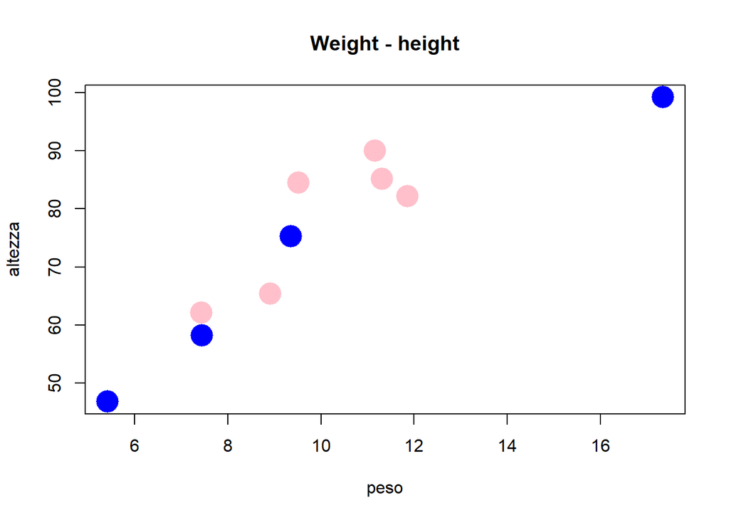

```r
babies = read.table("data/babies.tab")
# plot base relazione peso e altezza
plot(altezza ~ peso, data = babies,
     col = ifelse(genere == "f", "pink", "blue"),
     pch = 16, main = "Weight - height",
     cex = 3)
```

**Codice**

```r
babies$cat_weight = with(babies,
                         ifelse(
                           peso <= quantile(babies$peso)[2],
                           "light", ifelse(peso > quantile(babies$peso)[2] &
                                    peso > quantile(babies$peso)[4], "medium",
                                    "heavy")))
babies$cat_weight = factor(babies$cat_weight,
                           levels = c("light",
                                      "medium",
                                      "heavy"))


babies
```

```
       id genere      peso  altezza cat_weight
1   baby1      f  7.424646 62.07722      light
2   baby2      m  7.442727 58.18877      light
3   baby3      f  9.512598 84.52737      heavy
4   baby4      f 11.306349 85.13573     medium
....
```

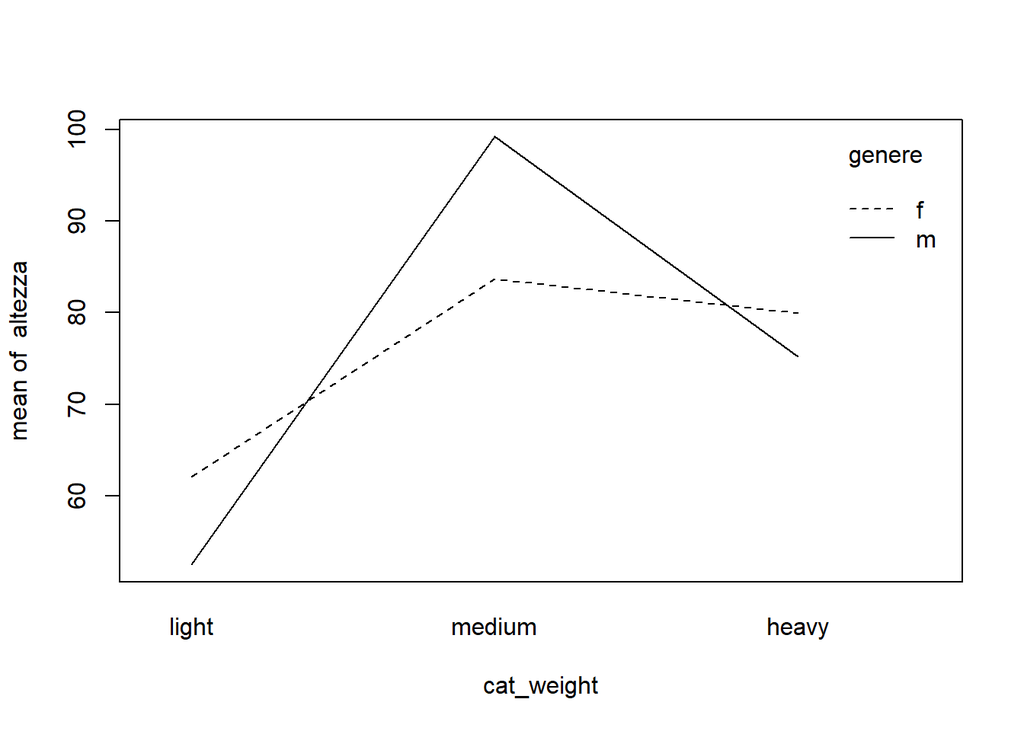

```r
with(babies,
     interaction.plot(cat_weight, genere, altezza))
```

## `ggplot2`

`ggplot2` (Grammar of Graphics plot, Wickman, 2016) è uno dei pacchetti migliori per ottenere dei grafici d’effetto con (relativamente) poco sforzo

```r
install.packages("ggplot2") # installa il pacchetto (da far correre solo la priuma volta)
library(ggplot2) # carica il pacchetto
```

La funzione `ggplot()` è las base del funzionamento del pacchetto. Il suo funzionamento prevede fondamentalmente 3 elementi principali:

```r
ggplot(data, # il dataframe da cui si vogliono prendere le variabili da plottare
       aes(x = x, y = y)) + # aes sta per aestetichs, definisce le variabili da plottare sulla x, y, i colori, le forme eccetera
  geom_graph.type() # definisce il tipo di grafico specifico che si vuole ottenere
```

(alcuni) Argomenti di `aes()`:

- `x` = variabile asse x
- `y` = variabile asse y
- `col` = variabile per distinguere i colori delle linee/contorni (factor o charcater)
- `fill` = variabile per distinguere il riempimento delle figure (factor o charcater)
- `shape` = variabile per distinguere la forma delle figure (factor o charcater)
- `size` = variabile per distinguere la grandezza delle figure (numeric o integer)
- ….

Alcuni tipi di grafici:

- `geom_point()` = plotta punti, se vengono date le variabili x e y è uno scatterplot
- `geom_line()` = plotta le linee
- `geom_boxplot()` = per ottenere i boxplot
- `geom_violin()` = per ottenere i violinplot
- `geom_hist()`: istogramma
- `geom_bar()`: barplot
- ….

Un esempio di scatterplot basato sul dataset `rock` (è un dataset interno a `R`)

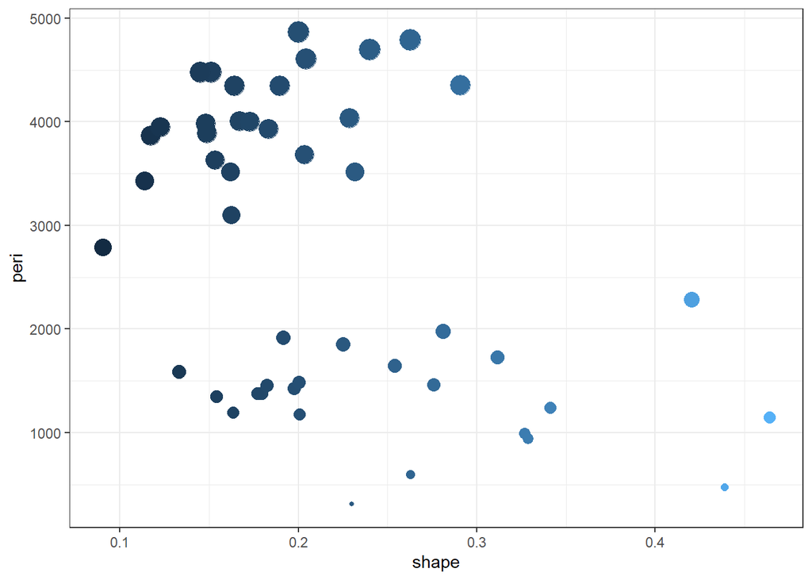

```r
ggplot(rock,
       aes(y=peri,
           x=shape,
           color =shape, # il colore viene definito sulla base della forma delle rocce
           size = peri)) + # la grandezza dei punti è definita dalla lunghezza del perimentro
  geom_point() + # produce lo scatterplot
  theme_bw() + # cambia lo sfondo del grafico
  theme(legend.position = "none") # toglie la legenda
```

Un altro esempio, dove si crea un data frame dove si hanno due a disposizione i tempi medi di risposta di due gruppi (variabile `gruppo`, livelli `a1` e `a2`) in tre wave temporali (variabile `tempo`, tre livelli, `b1`, `b2,`b3`):

```r
dat <- read.table(header=TRUE, text="
gruppo tempo rt
a1 b1 825
a1 b2 792
a1 b3 840
a2 b1 997
a2 b2 902
a2 b3 786
")
# le variabili gruppo e tempo vengono forzate ad essere factor
dat[,1:2] = lapply(dat[,1:2], as.factor)
```

A livello grafico, si può investigare se la relazione tra i tempi di risposta e la wave temporale cambia in base all’appartenenza di gruppo (interaction plot):

**Codice**

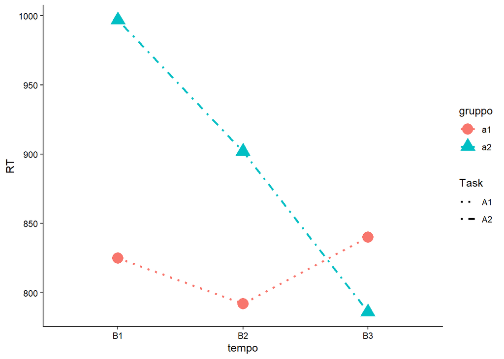

```r
ggplot(dat,
       aes(x = tempo,
           y = rt,
           group = gruppo,
           color= gruppo,
           shape = gruppo,
           linetype = gruppo)) +
  geom_point(size = 5) +
  geom_line(size=1)  + theme_classic() +
  ylab("RT") +  scale_linetype_manual("Task", values =c(3,4),
                                labels = c("A1", "A2")) +
  scale_x_discrete(labels = c("B1", "B2", "B3"))
```

## Scatter plot con `ggplot2`

**Codice**

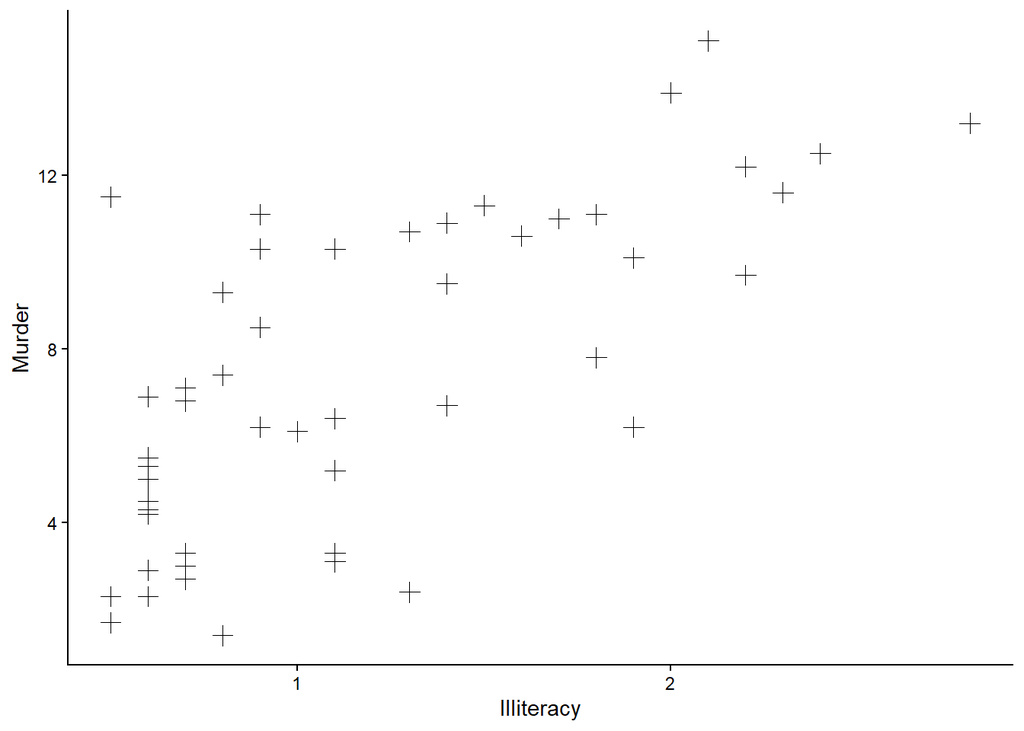

```r
states = data.frame(state.x77)
ggplot(states,  # raw data
               aes(x = Illiteracy, y = Murder)) +
  geom_point(size =3, pch=3) + theme_classic() + theme(legend.position = "none")
```

Per aggiungere la linea del modello di regressione con tanto di banda che indica l’errore standard della stima, si utilizza la funzione `geom_smooth()` (si possono specificare vari modelli oltre al modello lineare).

**Codice**

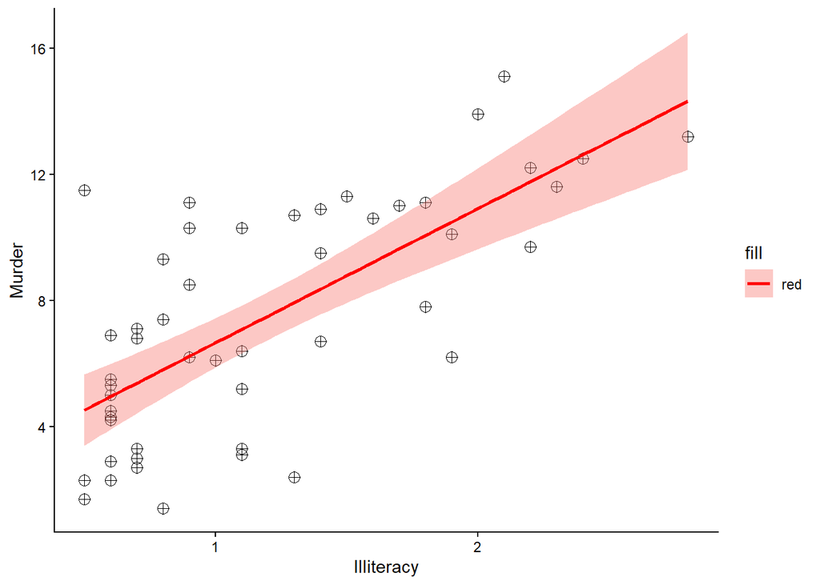

```r
ggplot(states,  # raw data
               aes(x = Illiteracy, y = Murder)) +
  geom_point(size =3, pch=10) + theme_classic() +
  geom_smooth(method="lm", color="red", aes(fill="red"))
```

## Multi plot

Per ottenere i multiplot combinando plot di analisi differenti (e.g, grafico delle statistiche descrittive e grafico dei risultati), è necessario installare il pacchetto `gridExtra`

```r
install.packages("gridExtra") # installa il pacchetto, da usare solo una volta
library(gridExtra) # carica il pacchetto e lo rende usabile
```

I multi plot si ottengono con la funzione `grid.arrange()`

**Codice**

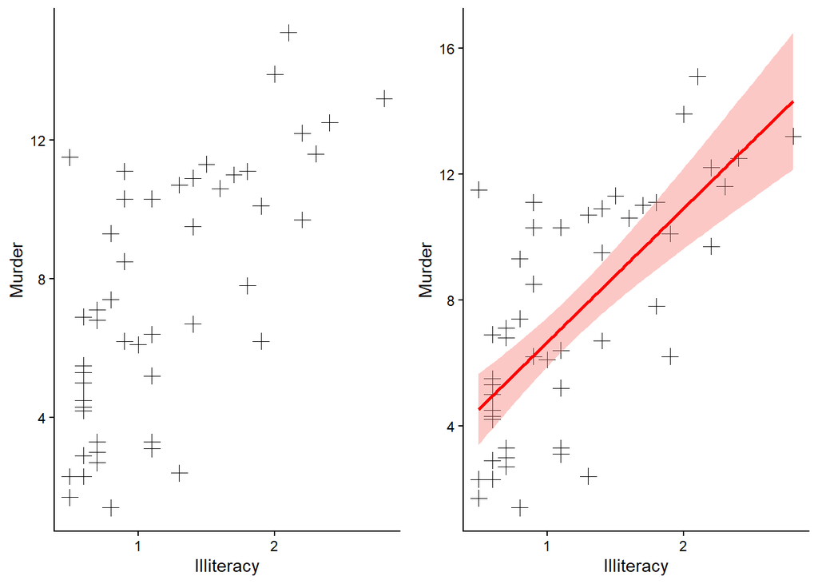

```r
murder_raw = ggplot(states,  # scatterplot
               aes(x = Illiteracy, y = Murder)) + geom_point(size =3, pch=3) + theme_classic() + theme(legend.position = "none")

murder_lm = ggplot(states,  # scatterplot con  modello di regerssione
               aes(x = Illiteracy, y = Murder)) + geom_point(size =3, pch=3) + theme_classic() +
  geom_smooth(method="lm", color="red", aes(fill="red")) + theme(legend.position = "none")
grid.arrange(murder_raw, # primo plot
             murder_lm, # secondo plot
             nrow=1) # numero di righe
```

## Multi plot II

```r
states = data.frame(state.x77, state.name = state.name,
                    state.region = state.region)
```

Nel caso in cui si voglia vedere la relazione tra due variabili nei vari livelli definiti da una terza variabile presente sempre nello stesso dataframe, si può usare la funzione `facet_wrap()` inclusa nel pacchetto `ggplot2`.

Ad esempio, prendendo come riferimento il dataset disponibile all’interno di R `state.x77` si vuole vedere se la relazione tra illiteracy e numero di omicidi varia al variare della macro area geografica considerata (Northeast, South, North Central, West)

**Codice**

```r
# si crea il dataframe corretto a partire da state.77
states = data.frame(state.x77, state.name = state.name,
                    state.region = state.region)

ggplot(states,
       aes(x = Illiteracy, y = Murder )) + geom_point() +
  facet_wrap(~state.region) # imposta automatiacamente di suddividere i grafici a seconda della state region
```

[output not shown]

## `boxplot()` e `violinplot()`

Per ottenere i boxplot e i violin plot, i dati devono essere riorganizzati in formato long, come nell’esempio qui sotto:

```
    id condition mean_time
1 sbj1         A  3.860907
2 sbj1         B  2.131674
3 sbj2         A  3.423382
4 sbj2         B  3.919431
5 sbj3         A  4.241790
6 sbj3         B  4.002556
```

Prendiamo ad esempio i dati del benessere, facendo esclusivamente riferimento ai punteggi di scala dell’autostima e del benessere:

```r
# seleziona solo le variabili di interesse
small = benessere[, c("ID", "score_au", "score_ben")]
# trasforma il dataframe in fromato long
score_long  = reshape(small,
        idvar = "ID",
        times =names(small)[-1],
        timevar = "score", v.names = "value",
        varying = list(names(small)[-1]),
        direction = "long")
head(score_long)
```

```
           ID    score value
1.score_au  1 score_au    33
2.score_au  2 score_au    40
3.score_au  3 score_au    38
4.score_au  4 score_au    38
5.score_au  5 score_au    26
6.score_au  6 score_au    33
```

Boxplot:

**Codice**

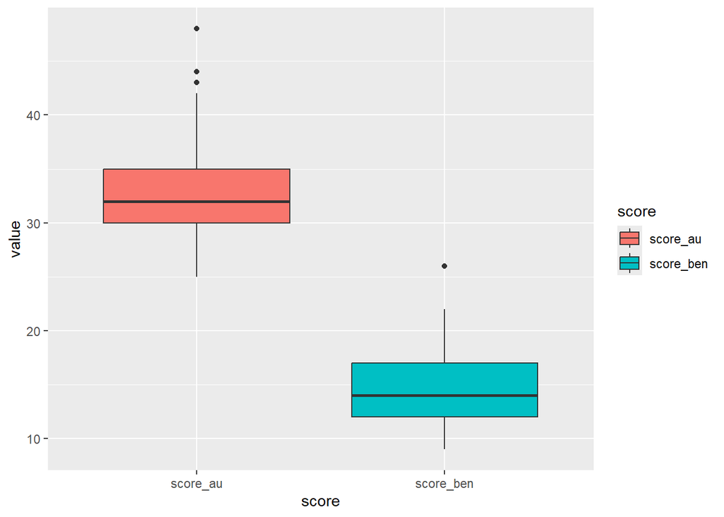

```r
ggplot(score_long,
       aes(x = score, y = value,
           fill = score)) +
  geom_boxplot()
```

Violinplot:

**Codice**

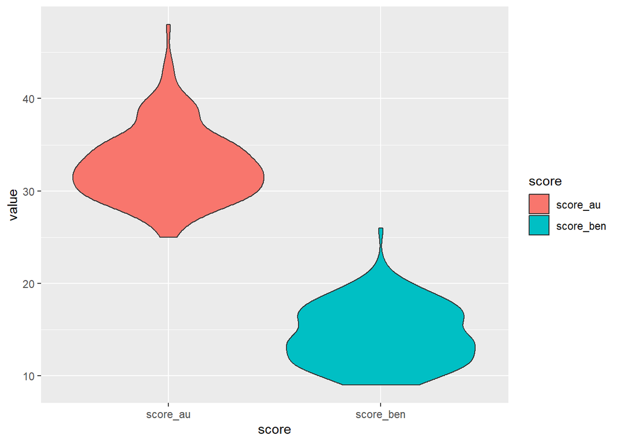

```r
ggplot(score_long,
       aes(x = score, y = value,
           fill = score)) +
  geom_violin()
```

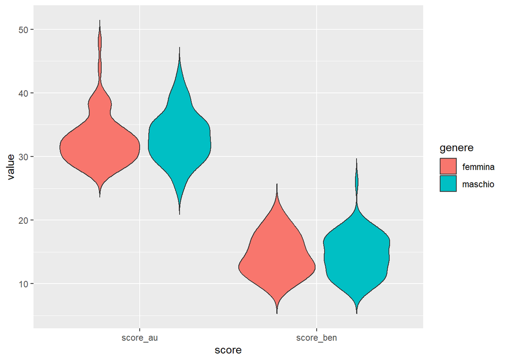

```r
score_long = merge(score_long, benessere[, c("ID", "genere")])

ggplot(score_long,
       aes(x = score, y = value,
           fill = genere)) + geom_violin(trim = FALSE)
```

## Grafici a barre ed istogrammi

`geom_hist()`: Istograma per variabili continue

`geom_bar()`: Grafico a barre per variabili categoriali

Argomenti

- `geom_bar(stat = "count")`: conta automaticamente le frequeunze per ogni categoria, **per cui non c’è bisogno di specificare una variabile y in `aes()`**
- `geom_bar(stat = "identity")`: associa un valore presente nel dataframe alla variabile y **che deve essere specificata in aes()`**

## `geom_bar(stat = "count")`:

Ad esempio, per ottenere le frequenze di risposta di un item:

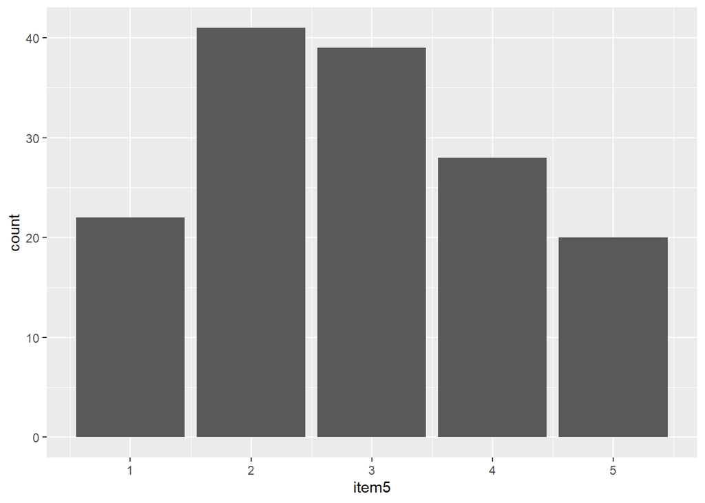

```r
ggplot(benessere,
       aes(x = item5)) + geom_bar(stat = "count") # conta automaticamente le frequeunze
```

## `geom_bar(stat = "identity")`

Per lo stesso item, si vuole plottare la proporzione di risposte epr ogni categoria $\rightarrow$ si vuole specificare il valore delll’asse y

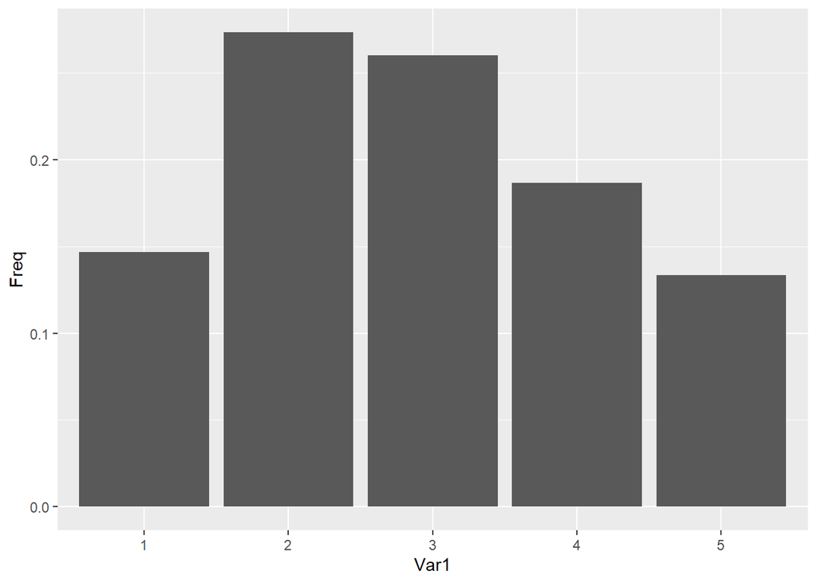

```r
item_5 = data.frame(table(benessere$item5)/nrow(benessere))
ggplot(item_5,
       aes(x = Var1,
           y = Freq)) + # viene specificata la variabile da plottare sulla y
  geom_bar(stat = "identity") # va specificato che si ha una variabile y
```